# Chapter 02 - Practice problems

**2E1**.

**2** and **4** because:
$$\frac{Pr(rain, Monday)}{Pr(Monday)} = \frac{Pr(rain|Monday)Pr(Monday)}{Pr(Monday)} = Pr(rain|Monday)$$

**2E2**.

$Pr(Monday|rain)$ corresponds to statement **3** ‘The probability that it is monday, given that it is raining.’

**2E3**.

The statement ‘the probability that it is Monday, given that it is raining?’ corresponds to expression **1** $Pr(Monday|rain)$ and expression **4** $Pr(rain|Monday) Pr(Monday)/ Pr(rain)$ because:
$$\frac{Pr(rain|Monday) Pr(Monday)}{Pr(rain)} = \frac{P(rain, Monday)}{Pr(rain)} = \frac{Pr(Monday|rain)Pr(rain)}{Pr(rain)} = Pr(Monday|rain)$$

**2E4**.

It means that given the current state of knowledge of an observer, the mode of **their** belief (posterior) distribution is at 0.7.

**2M1**.

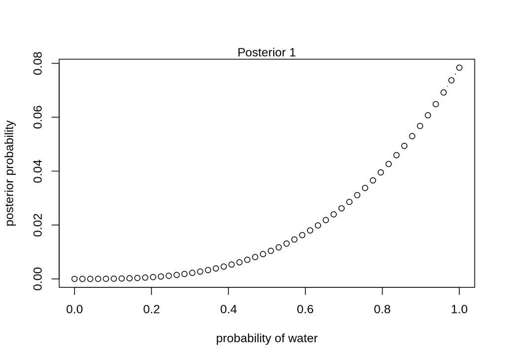

```r
n_grid <- 50
data1 <- list(W = 3, L = 0)
data2 <- list(W = 3, L = 1)
data3 <- list(W = 5, L = 2)

p_grid <- seq(0, 1, length.out = n_grid)

prior <- rep(1, n_grid)

posterior1_unstd <- dbinom(data1$W, data1$W + data1$L, p_grid) * prior
posterior1 <- posterior1_unstd / sum(posterior1_unstd)

plot(p_grid, posterior1, type = "b",
     xlab = "probability of water", ylab="posterior probability")
mtext("Posterior 1")
```

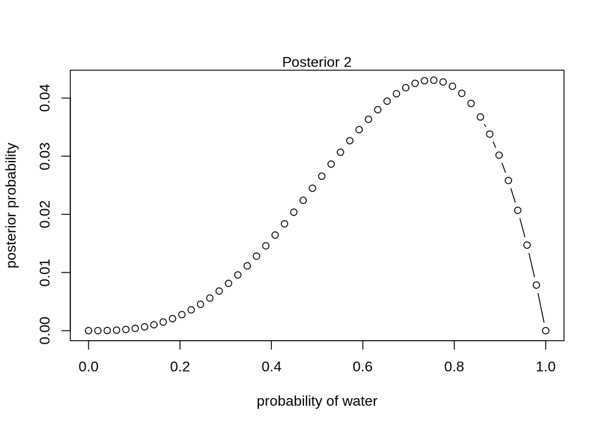

```r
posterior2_unstd <- dbinom(data2$W, data2$W + data2$L, p_grid) * prior
posterior2 <- posterior2_unstd / sum(posterior2_unstd)

plot(p_grid, posterior2, type = "b",
     xlab = "probability of water", ylab="posterior probability")
mtext("Posterior 2")
```

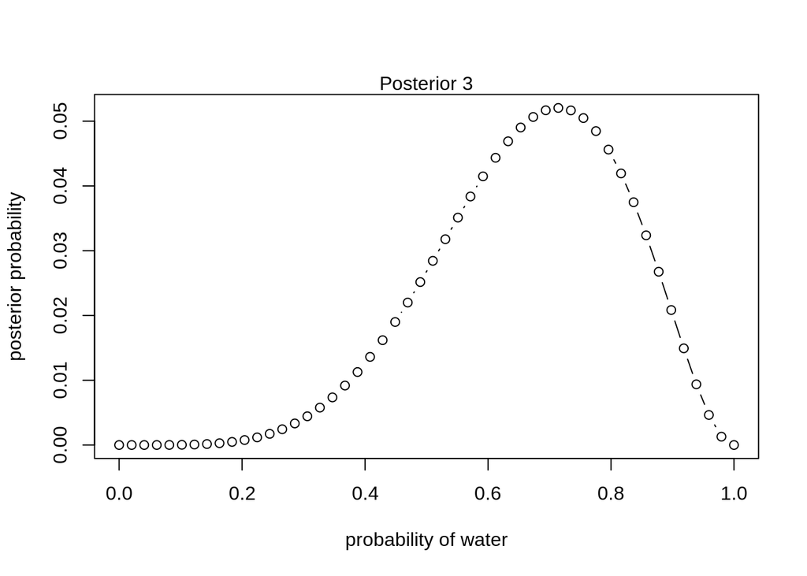

```r
posterior3_unstd <- dbinom(data3$W, data3$W + data3$L, p_grid) * prior
posterior3 <- posterior3_unstd / sum(posterior3_unstd)

plot(p_grid, posterior3, type = "b",
     xlab = "probability of water", ylab="posterior probability")
mtext("Posterior 3")
```

**2M2.**

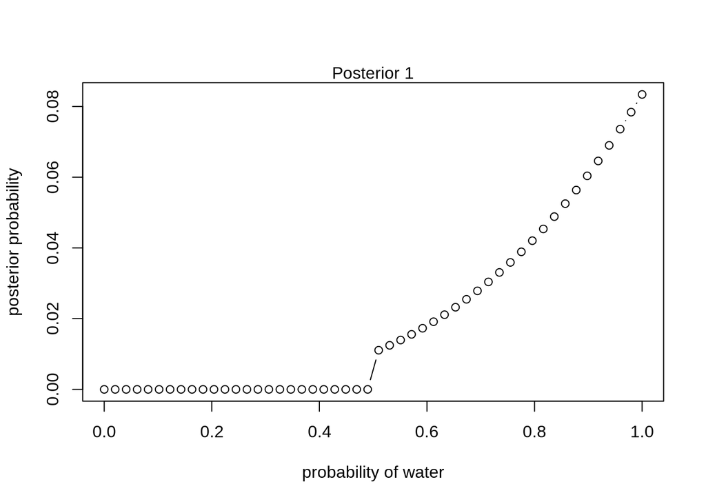

```r
n_grid <- 50
data1 <- list(W = 3, L = 0)
data2 <- list(W = 3, L = 1)
data3 <- list(W = 5, L = 2)

p_grid <- seq(0, 1, length.out = n_grid)

prior_constr <- ifelse(p_grid < 0.5 , 0, 1)

posterior1_unstd <- dbinom(data1$W, data1$W + data1$L, p_grid) * prior_constr
posterior1 <- posterior1_unstd / sum(posterior1_unstd)

plot(p_grid, posterior1, type = "b",
     xlab = "probability of water", ylab="posterior probability")
mtext("Posterior 1")
```

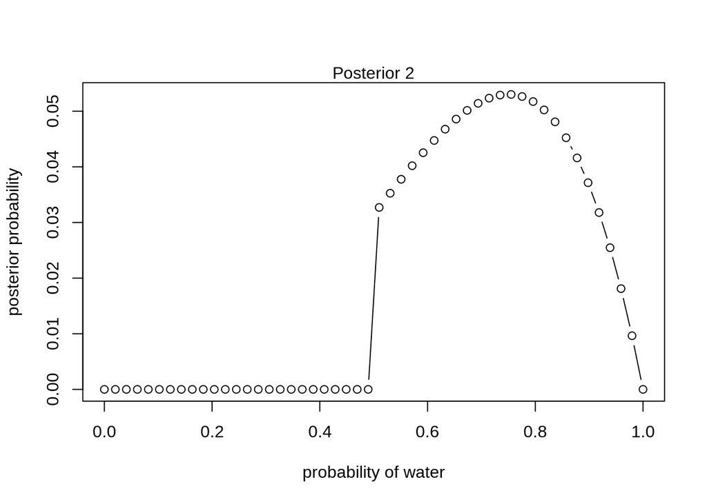

```r
posterior2_unstd <- dbinom(data2$W, data2$W + data2$L, p_grid) * prior_constr
posterior2 <- posterior2_unstd / sum(posterior2_unstd)

plot(p_grid, posterior2, type = "b",
     xlab = "probability of water", ylab="posterior probability")
mtext("Posterior 2")
```

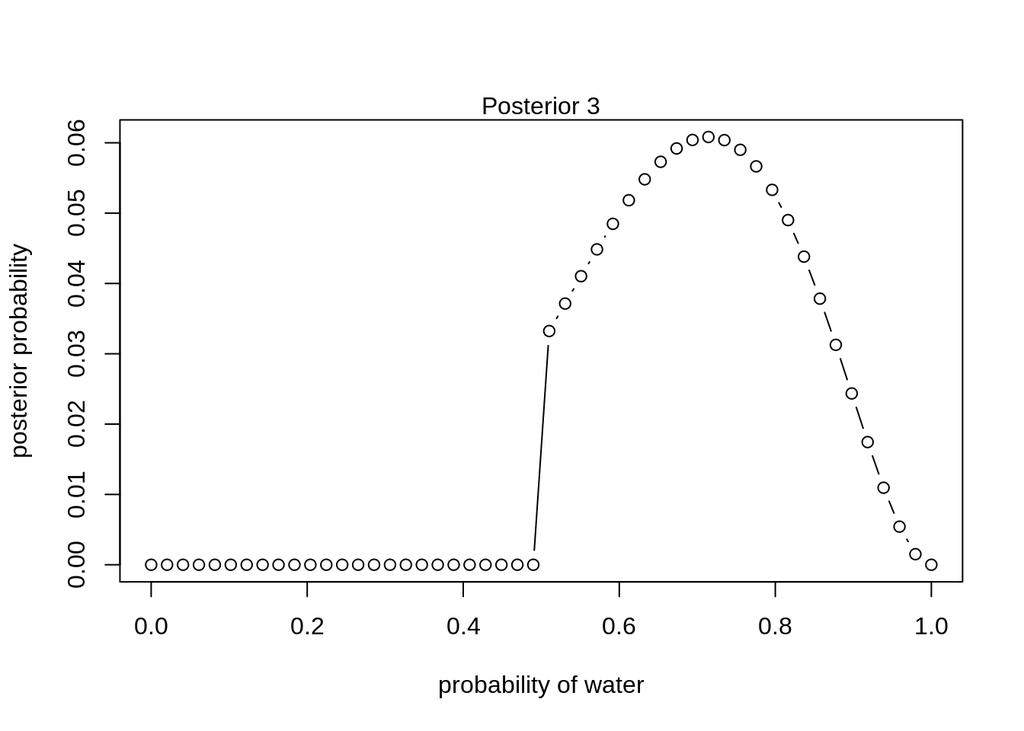

```r
posterior3_unstd <- dbinom(data3$W, data3$W + data3$L, p_grid) * prior_constr
posterior3 <- posterior3_unstd / sum(posterior3_unstd)

plot(p_grid, posterior3, type = "b",
     xlab = "probability of water", ylab="posterior probability")
mtext("Posterior 3")
```

**2H1** Given information:
$$P(A) = P(B) = 0.5 \\
P(T|A) = 0.1 \\
P(S|A) = 1 - P(T|A) = 0.9 \\
P(T|B) = 0.2 \\
P(S|B) = 1 - P(T|B) = 0.8$$

Information required:
$$P(T_2|T_1) = ?$$

We can “extend the conversation” (opposite of marginalization) to include the intervening variable of species:
$$P(T_2|T_1) = P(T_2|T_1,A)P(A|T_1) + P(T_2|T_1, B)P(B|T_1)$$
We will additionally assume that the births are conditionally independent (i.e., when we know the species, the fact that the first birth was a twin, gives us no additional information):
$$\begin{aligned}
P(T_2|T_1) &= P(T_2|A)P(A|T_1) + P(T_2|B)P(B|T_1) \\
&= 0.1 \times P(A|T_1) + 0.2 \times P(B|T_1) \\
\end{aligned}$$

Now using the Bayes’ theorem:
$$\begin{aligned}
P(A|T_1) &= \frac{P(T_1|A)P(A)}{P(T_1|A)P(A) + P(T_1|B)P(B)} = 1/3 \\
P(B|T_1) &= 1 - P(A|T_1) = 2/3
\end{aligned}$$
Finally, we obtain:
$$\begin{aligned}
P(T_2|T_1) &= P(T_2|A)P(A|T_1) + P(T_2|B)P(B|T_1) \\
&= 0.1 \times 1/3 + 0.2 \times 2/3 \\
&= 1/6
\end{aligned}$$

**2H2.** Information required:
$$P(A|T_1) = ?$$
We can use Bayes’ theorem as in H1:
$$P(A|T_1) = \frac{P(T_1|A)P(A)}{P(T_1|A)P(A) + P(T_1|B)P(B)} = 1/3$$

**2H3.** Information required:
$$P(A|T_1,S_2) = ?$$
Using Bayes’ theorem
$$P(A|T_1,S_2) = \frac{P(T_1,S_2|A)P(A)}{P(T_1, S_2)}$$
Due to independence of births (conditional on species), we have:
$$\begin{aligned}
P(T_1, S_2 | A) &= P(T_1|A)P(S_2|A) = 0.1 \times 0.9 = 0.09 \\
P(T_1, S_2 | B) &= p(T_1|B)P(S_2|B) = 0.2 \times 0.8 = 0.16 \\
p(T_1, S_2) &= P(T_1, S_2 | A)P(A) + P(T_1, S_2 | B)P(B) = 0.125 \\
P(A|T_1, S_2) &= \frac{0.09 \times 0.5}{0.125} = 0.36
\end{aligned}$$